# Relatório do PBI no Notebook

Por **Augusto Barros**

Para incorporar os relatório do PBI no notebook podemos usar a capacidade de renderização de html presente nas células de MarkDown.

Vamos criar um NB vazio:

[figure not shown]

Convertemos a célula para MD(Atalho: M):

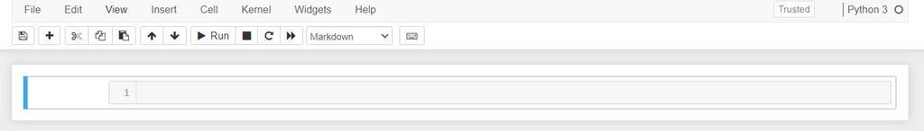

Vamos localizar o relatório que gostariamos de incorparar, e vamos abri-lo no PBI, no menu de comando clicamos em "Arquivo" e "Inserir relatório" > "Site/Portal":

[figure not shown]

Vamos copiar o Iframe e colar no markdown do nosso notebook:

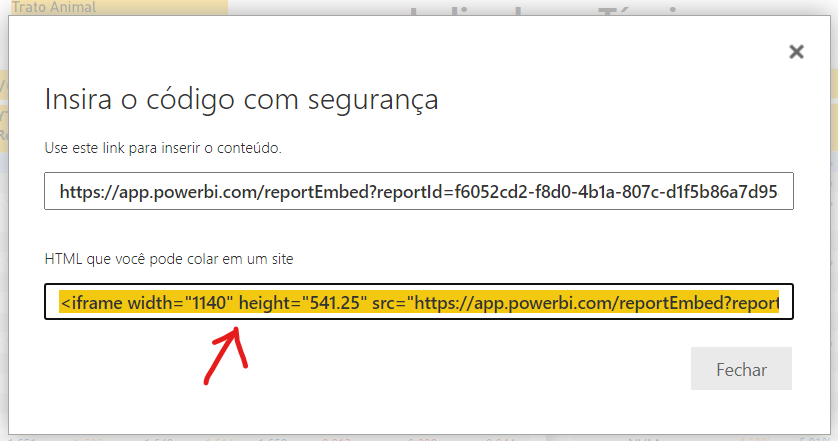

[figure not shown]

Executamos a célula:

[figure not shown]

O Relatório pode não renderizar mesmo, mas exportando o NB para HTML ele é exibido corretamente:

[figure not shown]

Abrindo o nb convertido:

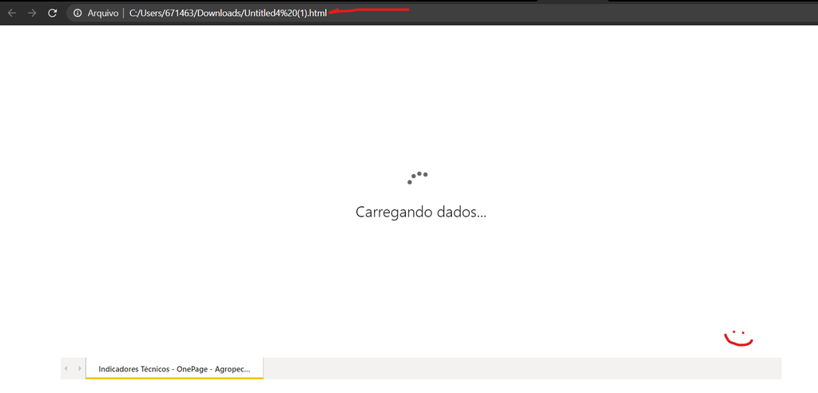

É possível fazer ajuste no tamanho da página além de outros controles:

[output not shown]

Nos parâmetros `width`, `height` que controlam largura e altura por exemplo.

### Exibindo o report com célula de código:

Criamos uma célula com o seguinte código:

```
from IPython.display import HTML

html = 'IFRAME_AQUI'

HTML(html)
```

[figure not shown]

> Podemos omitir o código (normalmente espanta usuários convencionais 😂) rodando esse comando de linha no cmd:

`jupyter nbconvert --execute --to html seu_notebook_aqui.ipynb --no-input --no-prompt`

Essa linha executa o NB e converte ele pra HTML, as flags `--no-input --no-prompt` vão omitir o código, exibindo apenas o output das células de código(quando a célula apresentar alguma saída)

O incorporamento permite a gente fazer o envio do relatório em uma página html isolada do ambiente do PBI, o leitor ainda precisa de acesso ao workspace para ver o relatório.

Espero ter ajudado.